## **Banded hare-wallaby**

### Blamed on cats

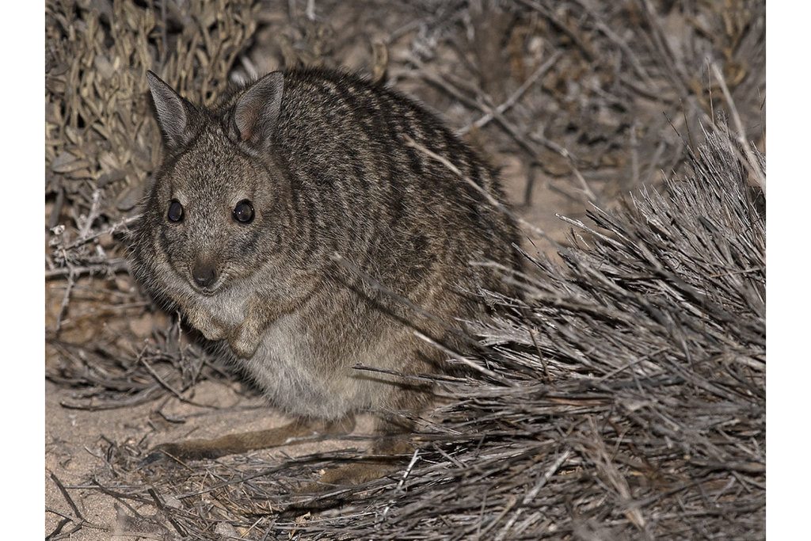

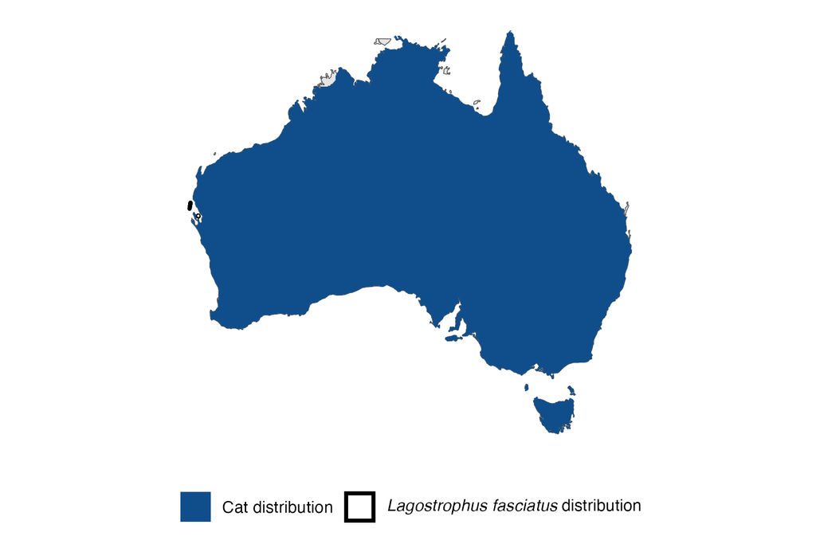

IUCN status: **Vulnerable**

EPBC Predator Threat Rating: **Moderate**

IUCN claim: *“The species presumably was extirpated from mainland Australia by a combination of predation by the Red Fox and feral cat and habitat disturbance.”*

### Studies in support

Cats were the main cause of mortality of a reintroduced, predator-inexperienced, hare-wallaby group (Hardman et al. 2016). Hare-wallabies were last confirmed in southwest Australia (two records) 15-76 years after cats arrived (Wallach and Lundgren 2025).

### Studies not in support

No studies

### Is the threat claim evidence-based?

No studies were found evidencing a negative association between banded hare-wallabies and cats. The fate of reintroduced animals is not a reliable proxy for the fate of populations.

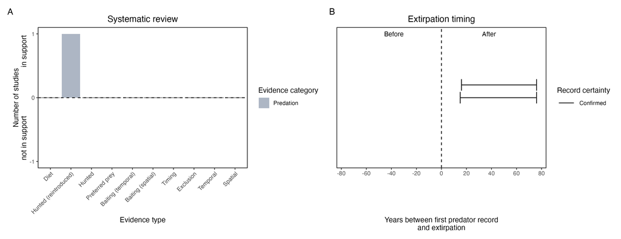

**Evidence linking *Lagostrophus fasciatus* to cats.** **A.** Systematic review of evidence for an association between *Lagostrophus fasciatus* and cats. Positive studies are in support of the hypothesis that cats contribute to the decline of *Lagostrophus fasciatus*, negative studies are not in support. Predation studies include studies documenting hunting or scavenging; baiting studies are associations between poison baiting and threatened mammal abundance where information on predator abundance is not provided; population studies are associations between threatened mammal and predator abundance. Gold borders indicate studies that meet qualities of scientific rigour. **B.** Last records of extirpated populations relative to earliest local records of cats. Error bars show minimum and maximum extinction intervals. Predator arrival records were digitized from Abbott 2008. See methods section in Wallach and Lundgren 2025 for details on evidence categories.

### References

Abbott, The spread of the cat, Felis catus, in Australia: re-examination of the current conceptual model with additional information. Conservation Science Western Australia 7 (2008).

EPBC. (2015) Threat Abatement Plan for Predation by Feral Cats. Environment Protection and Biodiversity Conservation Act 1999, Department of Environment, Government of Australia. (Table A1).

Hardman, B., Moro, D. and Calver, M., 2016. Direct evidence implicates feral cat predation as the primary cause of failure of a mammal reintroduction programme. Ecological Management & Restoration, 17(2), pp.152-158.

IUCN Red List. https://www.iucnredlist.org/ Accessed June 2023

Wallach A.D., Lundgren E.J. (2025) Review of evidence that foxes and cats cause extinctions of Australia’s endemic mammals. BioScience. DOI: 10.1093/biosci/biaf046